# Step 04 — Reproducibility capstone (teacher)

**_targets.R — your turn**

```r
library(targets)
library(tarchetypes)

# Packages every target needs (loaded in the targets worker process) ----
tar_option_set(
  packages = c(
    "tidymodels", "ranger", "glmnet", "kknn", "kernlab", "workflowsets", "yardstick",
    "vip", "kernelshap", "shapviz", "brulee", "ellmer",
    "rio", "janitor", "dplyr", "tidyr", "tibble"
  ),
)

# The LLM step needs OPENAI_API_KEY. The student's key lives in the workshop-root .Renviron
# (gitignored); read it here so the worker sees it. At build time the key is already in the
# environment, so the missing-file case is harmless. ----
if (file.exists("../../.Renviron")) readRenviron("../../.Renviron")

source("R/pipeline-fns.R")  # load_cohort(), explore_cohort(), split_cohort(), make_recipe(), ...

# The DAG: two input files fan out into the whole workshop arc, and the report is itself a target
# COMPILED from the intermediate ones, so document and inputs can never disagree. Each analysis is
# an EXPLICIT, INSPECTABLE target (tar_read() one at a time); tar_visnetwork(FALSE) draws the graph,
# and changing one input invalidates ONLY its downstream targets.
# NOTE: target names are deliberately distinct from the {recipes}/{rsample}/base symbols the
# pipeline functions call (recipe(), split, ...), so targets' static dep-analysis builds a clean DAG.
list(
  tar_target(cohort_file, "data-raw/heart_failure.csv", format = "file"),
  tar_target(notes_file,  "data-raw/hf_notes.csv",      format = "file"),
  tar_target(cohort,      load_cohort(cohort_file)),
  tar_target(eda,         explore_cohort(cohort)),
  tar_target(cohort_split, ___(cohort)),
  tar_target(prep_recipe,  make_recipe(cohort_split)),
  tar_target(base_compare, compare_models(cohort_split, prep_recipe)),
  tar_target(rf_model,     fit_rf(cohort_split, prep_recipe)),
  tar_target(vimp,         explain_model(rf_model, cohort)),
  tar_target(shap,         shap_explain(rf_model, cohort_split)),
  tar_target(mlp_curve,    learning_curve(cohort_split, prep_recipe)),
  tar_target(records,      extract_notes(notes_file)),
  tar_quarto(report, path = "report.qmd")
)
```

**_targets.R — solved**

```r
library(targets)
library(tarchetypes)

# Packages every target needs (loaded in the targets worker process) ----
tar_option_set(
  packages = c(
    "tidymodels", "ranger", "glmnet", "kknn", "kernlab", "workflowsets", "yardstick",
    "vip", "kernelshap", "shapviz", "brulee", "ellmer",
    "rio", "janitor", "dplyr", "tidyr", "tibble"
  ),
)

# The LLM step needs OPENAI_API_KEY. The student's key lives in the workshop-root .Renviron
# (gitignored); read it here so the worker sees it. At build time the key is already in the
# environment, so the missing-file case is harmless. ----
if (file.exists("../../.Renviron")) readRenviron("../../.Renviron")

source("R/pipeline-fns.R")  # load_cohort(), explore_cohort(), split_cohort(), make_recipe(), ...

# The DAG: two input files fan out into the whole workshop arc, and the report is itself a target
# COMPILED from the intermediate ones, so document and inputs can never disagree. Each analysis is
# an EXPLICIT, INSPECTABLE target (tar_read() one at a time); tar_visnetwork(FALSE) draws the graph,
# and changing one input invalidates ONLY its downstream targets.
# NOTE: target names are deliberately distinct from the {recipes}/{rsample}/base symbols the
# pipeline functions call (recipe(), split, ...), so targets' static dep-analysis builds a clean DAG.
list(
  tar_target(cohort_file, "data-raw/heart_failure.csv", format = "file"),
  tar_target(notes_file,  "data-raw/hf_notes.csv",      format = "file"),
  tar_target(cohort,      load_cohort(cohort_file)),
  tar_target(eda,         explore_cohort(cohort)),
  tar_target(cohort_split, split_cohort(cohort)),
  tar_target(prep_recipe,  make_recipe(cohort_split)),
  tar_target(base_compare, compare_models(cohort_split, prep_recipe)),
  tar_target(rf_model,     fit_rf(cohort_split, prep_recipe)),
  tar_target(vimp,         explain_model(rf_model, cohort)),
  tar_target(shap,         shap_explain(rf_model, cohort_split)),
  tar_target(mlp_curve,    learning_curve(cohort_split, prep_recipe)),
  tar_target(records,      extract_notes(notes_file)),
  tar_quarto(report, path = "report.qmd")
)
```

**Compiled report**

This report is **compiled by the `targets` pipeline itself** (`tarchetypes::tar_quarto()`). It does **not** re-run the analysis inline — it **reads the intermediate targets** with `tar_read()`, so what you see is, by construction, exactly what the pipeline produced upstream. The whole workshop arc — explore, compare the base techniques, the forest’s importance and SHAP, a deep-net learning curve, and the typed LLM extraction — is **one `tar_make()`** away. Change one input and only its downstream targets rebuild; change nothing and the whole thing skips.

```r
library(targets)
library(ggplot2)
library(dplyr)
library(shapviz)
```

## 1 · Exploration — who is in the cohort

```r
eda <- tar_read(eda)
eda$balance
```

```
# A tibble: 2 × 2
  outcome      n
  <fct>    <int>
1 died        96
2 survived   203
```

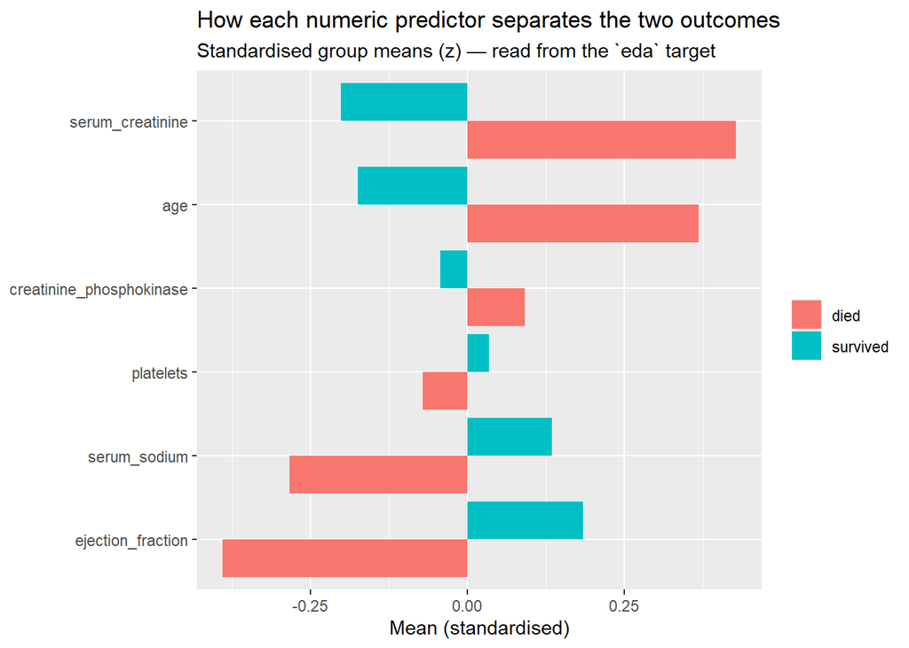

```r
ggplot(eda$separation, aes(x = mean_z, y = reorder(variable, mean_z), fill = outcome)) +
  geom_col(position = "dodge") +
  labs(
    title = "How each numeric predictor separates the two outcomes",
    subtitle = "Standardised group means (z) — read from the `eda` target",
    x = "Mean (standardised)", y = NULL, fill = NULL,
  )
```

The classes are imbalanced (more survivors), and `ejection_fraction`, `serum_creatinine`, and `age` already pull the two groups apart before any model is fit.

## 2 · Base techniques — the four Basic learners, compared

```r
base_compare <- tar_read(base_compare)
base_compare
```

```
# A tibble: 4 × 4
  model  roc_auc std_err  rank
  <chr>    <dbl>   <dbl> <int>
1 rf       0.778  0.0215     1
2 svm      0.746  0.0105     2
3 penlog   0.731  0.0279     3
4 knn      0.636  0.0277     4
```

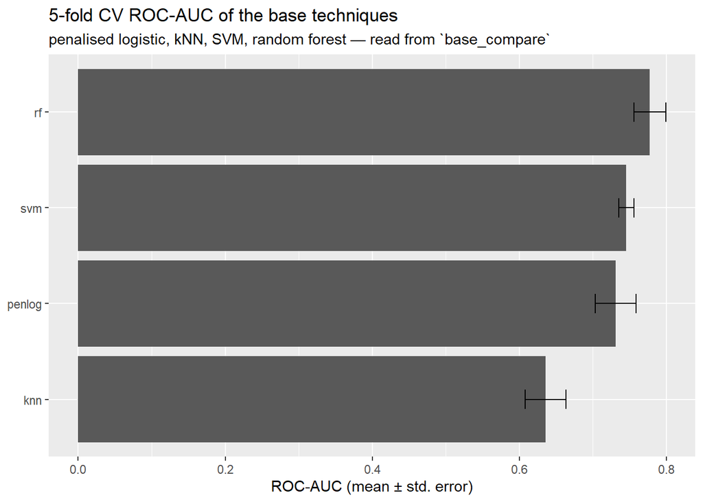

```r
ggplot(base_compare, aes(x = roc_auc, y = reorder(model, roc_auc))) +
  geom_col() +
  geom_errorbarh(aes(xmin = roc_auc - std_err, xmax = roc_auc + std_err), height = 0.2) +
  labs(
    title = "5-fold CV ROC-AUC of the base techniques",
    subtitle = "penalised logistic, kNN, SVM, random forest — read from `base_compare`",
    x = "ROC-AUC (mean ± std. error)", y = NULL,
  )
```

The random forest is the robust winner — the model the rest of the pipeline keeps.

## 3 · Permutation VIMP — what the forest relies on

```r
vimp <- tar_read(vimp)
vimp
```

```
# A tibble: 11 × 3
   Variable                 Importance    StDev
   <chr>                         <dbl>    <dbl>
 1 ejection_fraction           0.109   0.00866
 2 serum_creatinine            0.0926  0.00784
 3 age                         0.0647  0.00766
 4 platelets                   0.0294  0.00293
 5 creatinine_phosphokinase    0.0278  0.00161
 6 serum_sodium                0.0208  0.00247
 7 sex                         0.00513 0.00155
 8 anaemia                     0.00488 0.000747
 9 high_blood_pressure         0.00445 0.00111
10 smoking                     0.00317 0.000741
11 diabetes                    0.00268 0.000588
```

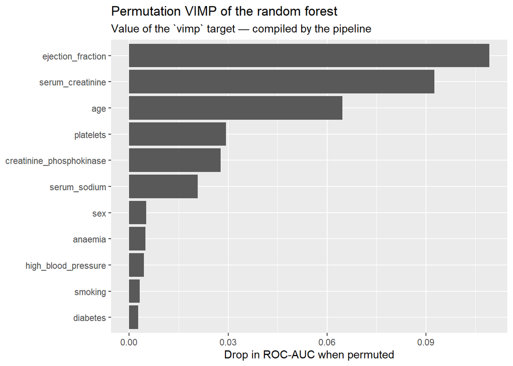

```r
vimp |>
  mutate(Variable = stats::reorder(Variable, Importance)) |>
  ggplot(aes(x = Importance, y = Variable)) +
  geom_col() +
  labs(
    title = "Permutation VIMP of the random forest",
    subtitle = "Value of the `vimp` target — compiled by the pipeline",
    x = "Drop in ROC-AUC when permuted", y = NULL,
  )
```

`ejection_fraction`, `serum_creatinine`, and `age` lead — the reliance ordering the forest learned.

## 4 · Agnostic SHAP — the same forest, model-agnostic

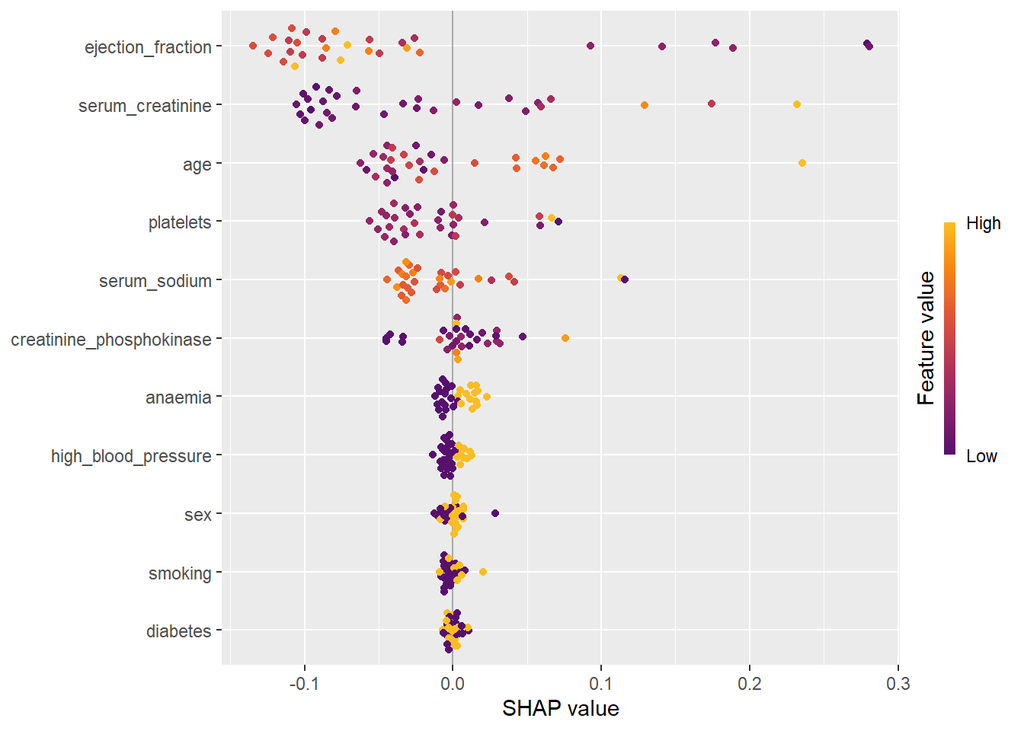

```r
shap <- tar_read(shap)
sv_importance(shap, kind = "beeswarm")
```

Kernel SHAP, treating the forest as a black box, recovers the same drivers — agreement between two independent explainers, both read from the DAG.

## 5 · A deep-net learning curve

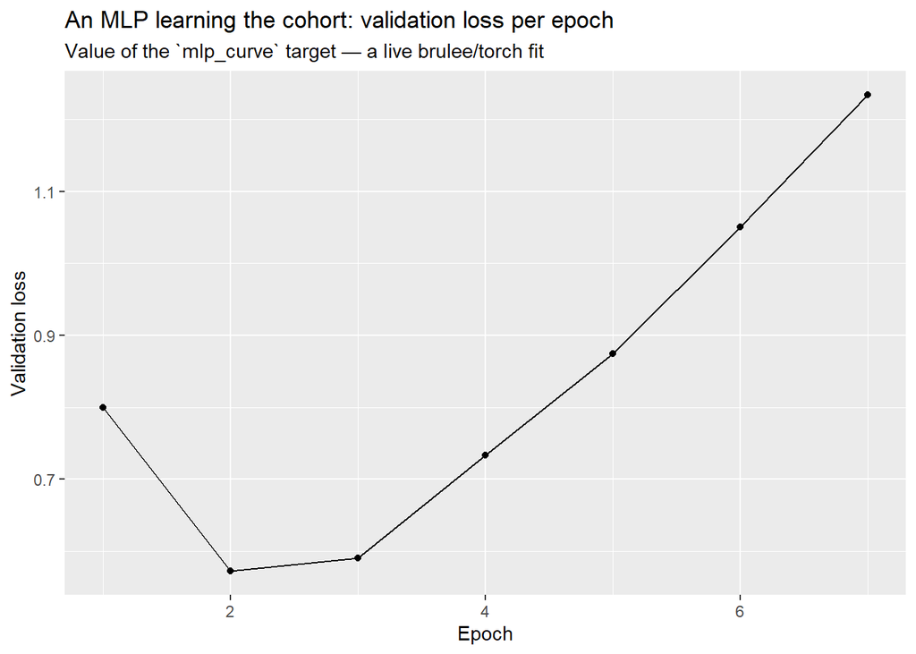

```r
mlp_curve <- tar_read(mlp_curve)
ggplot(mlp_curve, aes(x = epoch, y = valid_loss)) +
  geom_line() +
  geom_point() +
  labs(
    title = "An MLP learning the cohort: validation loss per epoch",
    subtitle = "Value of the `mlp_curve` target — a live brulee/torch fit",
    x = "Epoch", y = "Validation loss",
  )
```

Validation loss falls to a minimum, then creeps back up as the net starts to overfit; early stopping halts training a few epochs later — the U and the early-stopping rule from §02, now on the tabular cohort and re-run by the pipeline.

## 6 · Typed LLM extraction — the ETL, one row per note

```r
records <- tar_read(records)
records
```

```
# A tibble: 12 × 5
     age ejection_fraction on_betablocker primary_dx   serum_creatinine
   <int>             <dbl> <lgl>          <fct>                   <dbl>
 1    78                30 TRUE           ischemic                    0
 2    62                25 FALSE          ischemic                    0
 3    55                58 TRUE           hypertensive                0
 4    70                40 TRUE           hypertensive                0
 5    64                45 TRUE           valvular                    0
 6    71                35 FALSE          valvular                    0
 7    67                22 TRUE           ischemic                    0
 8    80                -1 TRUE           hypertensive               -1
 9    42                20 TRUE           other                       0
10    58                38 FALSE          other                       0
11    75                28 FALSE          ischemic                    0
12    53                50 TRUE           hypertensive                0
```

Because this document is a downstream **target**, re-rendering it is governed by input hashes: identical inputs ⇒ an all-skip rebuild, the signature of reproducibility. Touch one upstream input and `tar_visnetwork()` shows exactly which branch — and only that branch — goes stale.